# HW05

Noah Dunn

October 19, 2018

### Problem 1

```r
boarddata <- read.csv("particleboard.csv")
```

## 1.

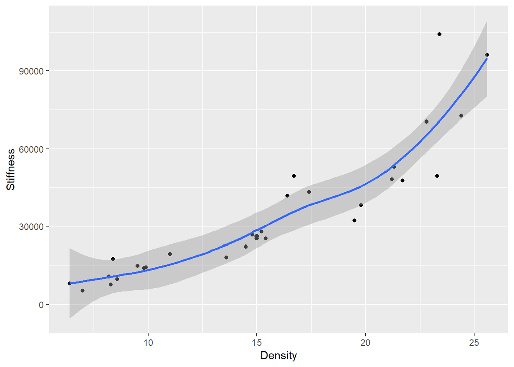

```r
ggplot(boarddata, aes(x=Density, y=Stiffness)) +
  geom_point() +
  geom_smooth() +
  xlab("Density") +
  ylab("Stiffness")
```

There is a distinct curvature in this graph, noticeably curving upwards.

## 2.

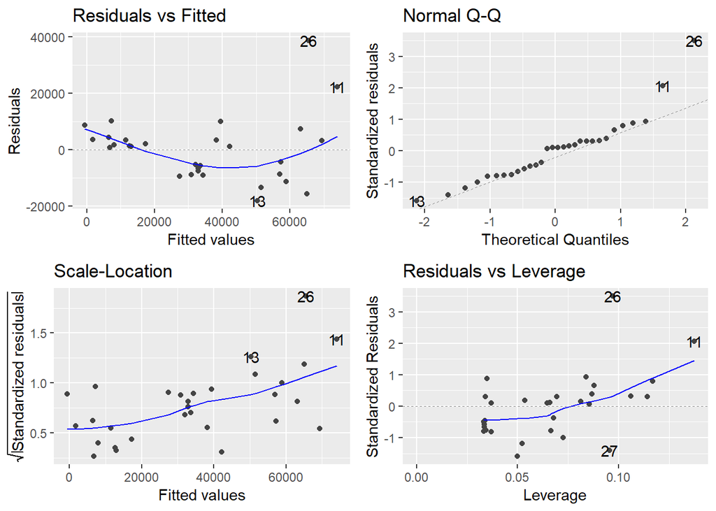

```r
boarddata.lm <- lm(Stiffness ~ Density, data= boarddata)
autoplot(boarddata.lm)
```

```r
summary(boarddata.lm)
```

```
##
## Call:
## lm(formula = Stiffness ~ Density, data = boarddata)
##
## Residuals:
##    Min     1Q Median     3Q    Max
## -18116  -8413   1121   3535  38695
##
## Coefficients:
##             Estimate Std. Error t value Pr(>|t|)
## (Intercept)   -25434       6105  -4.166 0.000269 ***
## Density         3885        370  10.500 3.25e-11 ***
## ---
## Signif. codes:  0 '***' 0.001 '**' 0.01 '*' 0.05 '.' 0.1 ' ' 1
##
## Residual standard error: 11620 on 28 degrees of freedom
## Multiple R-squared:  0.7975, Adjusted R-squared:  0.7902
## F-statistic: 110.2 on 1 and 28 DF,  p-value: 3.245e-11
```

Normality appears to be fairly safe to utilize, although there is a single potentially drastic outlier. The residuals plot, much like the base scatter plot appears to increase as fitted values increase, which is not desired when looking for equal variance.

## 3.

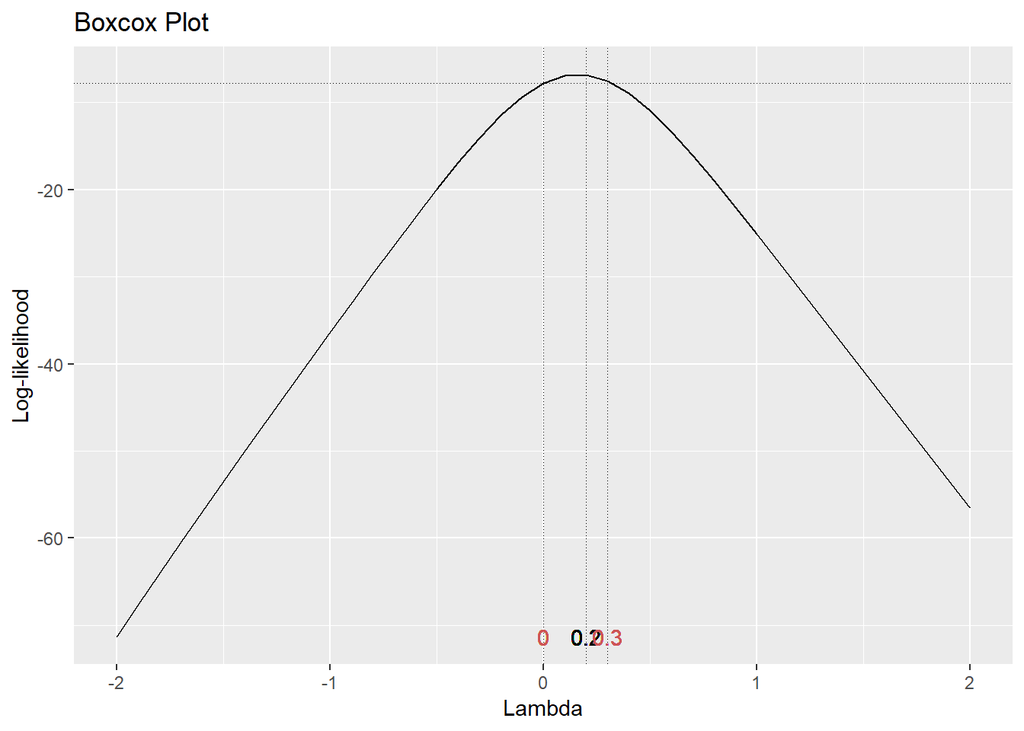

```r
gg_boxcox(boarddata.lm)
```

The range of transformation values occur over the interval 0-0.3. Given this information. A transformation of log(Stiffness) seems the most appropriate.

## 4.

```r
boarddata <- boarddata %>%
  mutate(log.stiffness = log(Stiffness))
```

## 5.

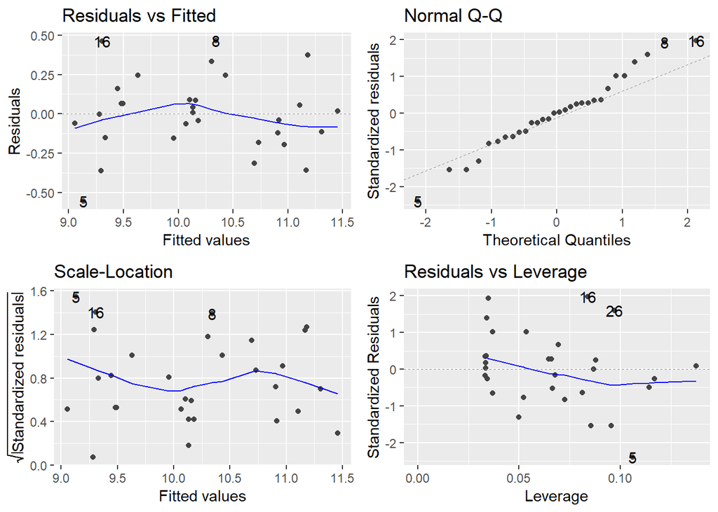

```r
boarddatalog.lm <- lm(log.stiffness ~ Density, data= boarddata)
autoplot(boarddatalog.lm)
```

```r
summary(boarddatalog.lm)
```

```
##
## Call:
## lm(formula = log.stiffness ~ Density, data = boarddata)
##
## Residuals:
##      Min       1Q   Median       3Q      Max
## -0.55566 -0.14340  0.00343  0.08721  0.46607
##
## Coefficients:
##             Estimate Std. Error t value Pr(>|t|)
## (Intercept) 8.257421   0.128650   64.19  < 2e-16 ***
## Density     0.124923   0.007798   16.02 1.24e-15 ***
## ---
## Signif. codes:  0 '***' 0.001 '**' 0.01 '*' 0.05 '.' 0.1 ' ' 1
##
## Residual standard error: 0.2449 on 28 degrees of freedom
## Multiple R-squared:  0.9016, Adjusted R-squared:  0.8981
## F-statistic: 256.7 on 1 and 28 DF,  p-value: 1.244e-15
```

## 6.

```r
boarddata <- boarddata %>%
  mutate(Lower.CI = exp(predict(boarddatalog.lm, interval="conf")[,2]),
         Upper.CI = exp(predict(boarddatalog.lm, interval="conf")[,3]),
         Lower.PI = exp(predict(boarddatalog.lm, interval="pred")[,2]),
         Upper.PI = exp(predict(boarddatalog.lm, interval="pred")[,3]),
  Fitted = exp(fitted(boarddatalog.lm)))
```

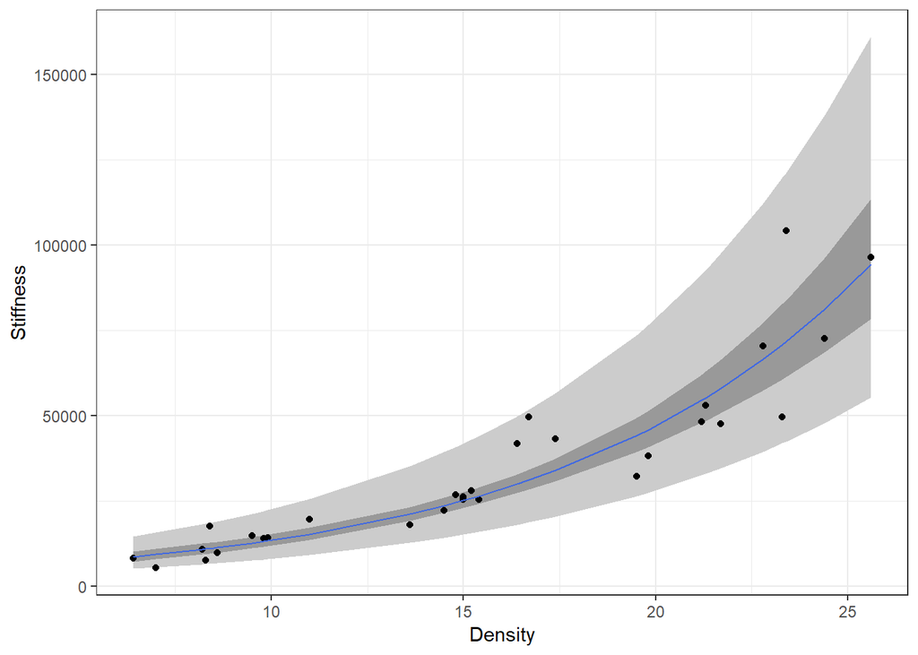

```r
ggplot(boarddata) +
  geom_ribbon(aes(x=Density, ymin=Lower.PI, ymax=Upper.PI), fill="gray80") +
  geom_ribbon(aes(x=Density, ymin=Lower.CI, ymax=Upper.CI), fill="gray60") +
  geom_point(aes(x=Density, y=Stiffness) ) +
  geom_line(aes(x=Density, y=Fitted), color="royalblue") +
  labs(x="Density", y="Stiffness") +
  theme_bw()
```

## 7.

We observe that as particleboard density increases, particleboard Stiffness also tends to increase at what appears to be an exponential rate.

### Problem 2

```r
electiondata <- read.csv("election1992.csv")
```

## 1.

```r
electiondata.ohio <- electiondata %>%
  filter(State == "OH")
```

## 2.

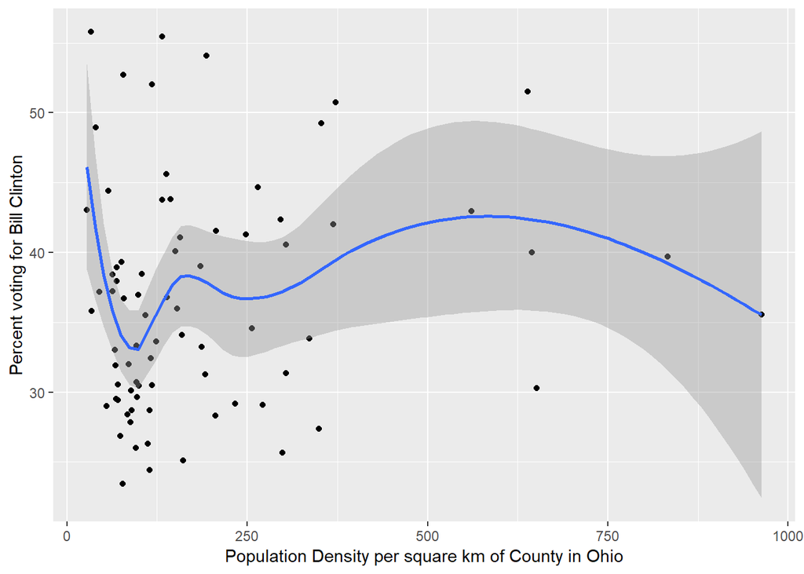

```r
ggplot(electiondata.ohio, aes(x=Population, y=Percent)) +
  geom_point() +
  geom_smooth() +
  xlab("Population Density per square km of County in Ohio") +
  ylab("Percent voting for Bill Clinton")
```

## 3.

```r
electiondata.ohio <- electiondata.ohio %>%

  mutate(Q1 = quantile(Population)[2],
         Median = quantile(Population)[3],
         Q3 = quantile(Population)[4],
         Quartile = case_when(Population < Q1 ~ "FirstQ",
                              Population >= Q1 & Population < Median ~ "SecondQ",
                              Population >= Median & Population <= Q3 ~ "ThirdQ",
                              Population > Q3 ~ "FourthQ"),
         Quartile = factor(Quartile, levels = c("FirstQ", "SecondQ", "ThirdQ", "FourthQ")))
```

## 4.

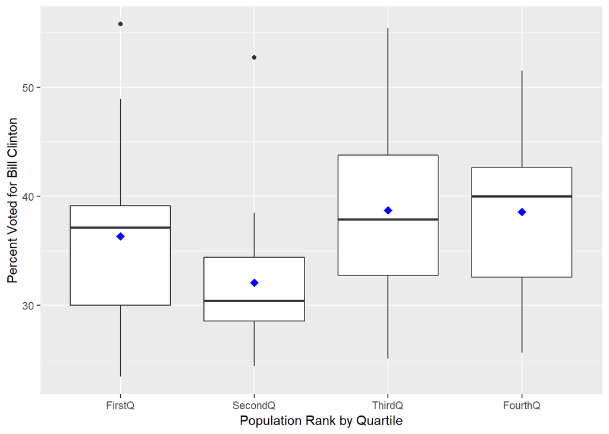

```r
ggplot(electiondata.ohio,aes(x=Quartile,y =Percent)) +
  geom_boxplot()+
  xlab("Population Rank by Quartile")+
  ylab("Percent Voted for Bill Clinton")+
  stat_summary(fun.y=mean, colour="blue", geom="point",
                           shape=18, size=3,show_guide = FALSE)
```

## 5.

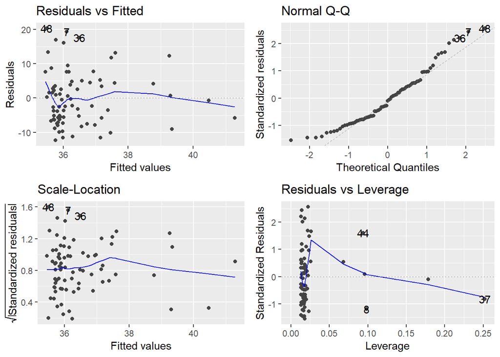

```r
electiondata.ohio.lm <- lm(Percent ~ Population, data= electiondata.ohio)
autoplot(electiondata.ohio.lm)
```

```r
summary(electiondata.ohio.lm)
```

```
##
## Call:
## lm(formula = Percent ~ Population, data = electiondata.ohio)
##
## Residuals:
##      Min       1Q   Median       3Q      Max
## -12.3143  -6.2026  -0.7553   4.4226  20.2954
##
## Coefficients:
##              Estimate Std. Error t value Pr(>|t|)
## (Intercept) 35.285212   1.317943  26.773   <2e-16 ***
## Population   0.006231   0.005049   1.234    0.221
## ---
## Signif. codes:  0 '***' 0.001 '**' 0.01 '*' 0.05 '.' 0.1 ' ' 1
##
## Residual standard error: 7.998 on 75 degrees of freedom
## Multiple R-squared:  0.0199, Adjusted R-squared:  0.006832
## F-statistic: 1.523 on 1 and 75 DF,  p-value: 0.221
```

Normality and equal variance of the residual error both appear to look fine for conducting analysis. However, this particular model has a p-value of 0.221, making it insignificant to do any form of prediction.

## 6.

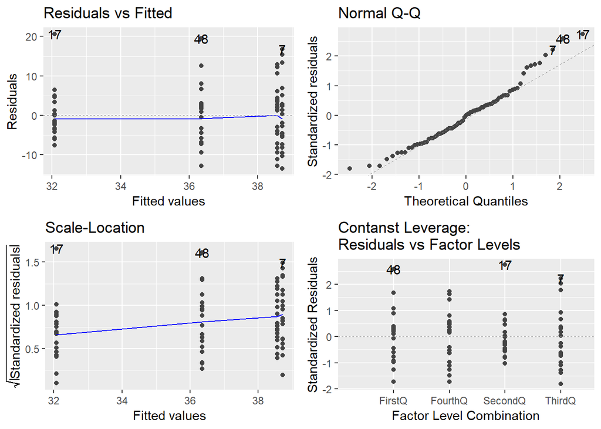

```r
electiondata.ohio.lm <- lm(Percent ~ Quartile, data= electiondata.ohio)
autoplot(electiondata.ohio.lm)
```

```r
summary(electiondata.ohio.lm)
```

```
##
## Call:
## lm(formula = Percent ~ Quartile, data = electiondata.ohio)
##
## Residuals:
##      Min       1Q   Median       3Q      Max
## -13.6020  -5.4820  -0.0758   3.8016  20.6442
##
## Coefficients:
##                 Estimate Std. Error t value Pr(>|t|)
## (Intercept)       36.355      1.769  20.546   <2e-16 ***
## QuartileSecondQ   -4.279      2.502  -1.710   0.0915 .
## QuartileThirdQ     2.367      2.471   0.958   0.3412
## QuartileFourthQ    2.214      2.502   0.885   0.3792
## ---
## Signif. codes:  0 '***' 0.001 '**' 0.01 '*' 0.05 '.' 0.1 ' ' 1
##
## Residual standard error: 7.713 on 73 degrees of freedom
## Multiple R-squared:  0.1128, Adjusted R-squared:  0.07636
## F-statistic: 3.094 on 3 and 73 DF,  p-value: 0.03211
```

Normality and equal variance of the residual error of this set appear sufficient. This model is also significant at the 95% confidence level.

## 7.

The first model is very simple, as it does not have any categorization based on ranges and deals exclusively with measuring voting percentage based on an each counties’ population density. Model 2 is more complex, as we deal with 4 distinct categories based on quartile ranges of population density.

The first model is not significant at any reasonable confidence level, and the second model is significant at a 95% confidence level. Within the model’s significance, The Second Quartile experiences a negatively significant difference of 4.279 percent less people voting for Bill Clinton compared to the first quartile at a 90% confidence level.

The first model accounts for 0.6% of the variation in percent voting for Bill Clinton. The second accounts for 7.6% of the variation in percent voting for Bill Clinton.

I would argue the second model is better than the first, although neither are overtly compelling. The first suffer a low variation accountability, and it lacks any meaningful significance. The second model is significant, and although it only accounts for the significance of a single predictor at the 90% confidence level, this is better than no significance at all. It also possesses a higher variation accounted for.